# Ad Exposure on Social Media

Katherine Te Hiko

[figure not shown]

## Introduction

Over several weeks, I logged my social media usage across 20-minute phone sessions, recording how many ads I encountered, how many I interacted with, whether they felt relevant, and whether any repeated. This story explores what the data reveals about the nature of advertising across social media platforms.

## Which Platform Shows the Most Ads?

Not all social media platforms deliver the same advertising experience. The chart below shows the average number of ads seen per 20-minute session on each platform.

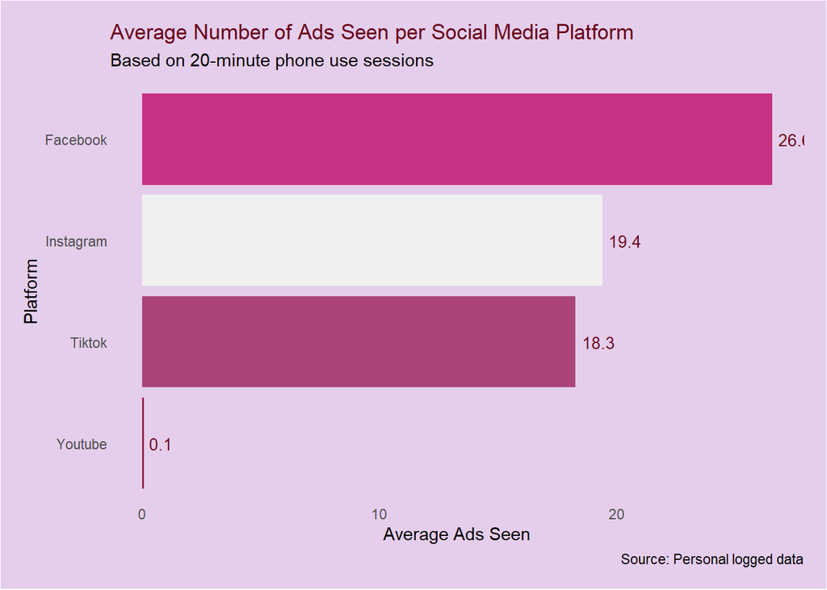

This plot revels that facebook has the highest number of ads recorded within a 20 minute period, with an average of 26.6 ads, whereas youtube has the lowest number of recorded ads with an average of 0.1 ads within a 20 minute session.

## Do I Actually Engage With the Ads I See?

Seeing an ad and interacting with it are very different things. The scatter plot below shows the relationship between how many ads I saw and how many I interacted with across all sessions.

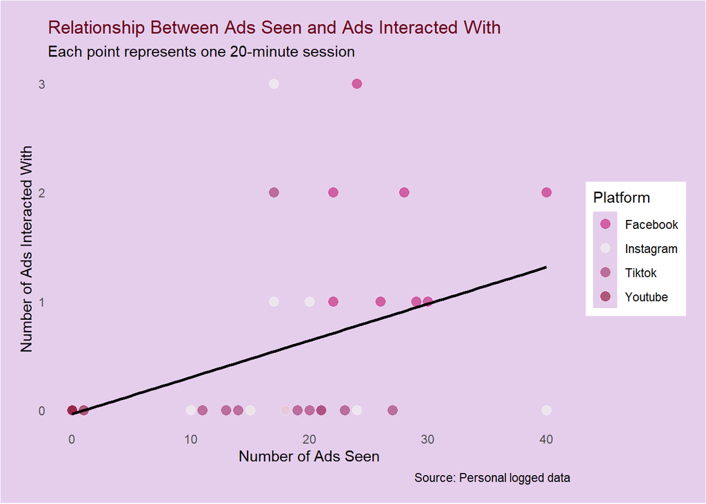

Despite the graph looking linear in a positive direction, my interaction rate remained consistently low, even with a large number of ads seen, suggesting that most ads, regardless of platform, did not feel compelling enough to engage with.

## How Did My Ad Exposure Change Over Time?

Finally, looking at how ad exposure changed across the logging period reveals interesting patterns in my phone usage habits

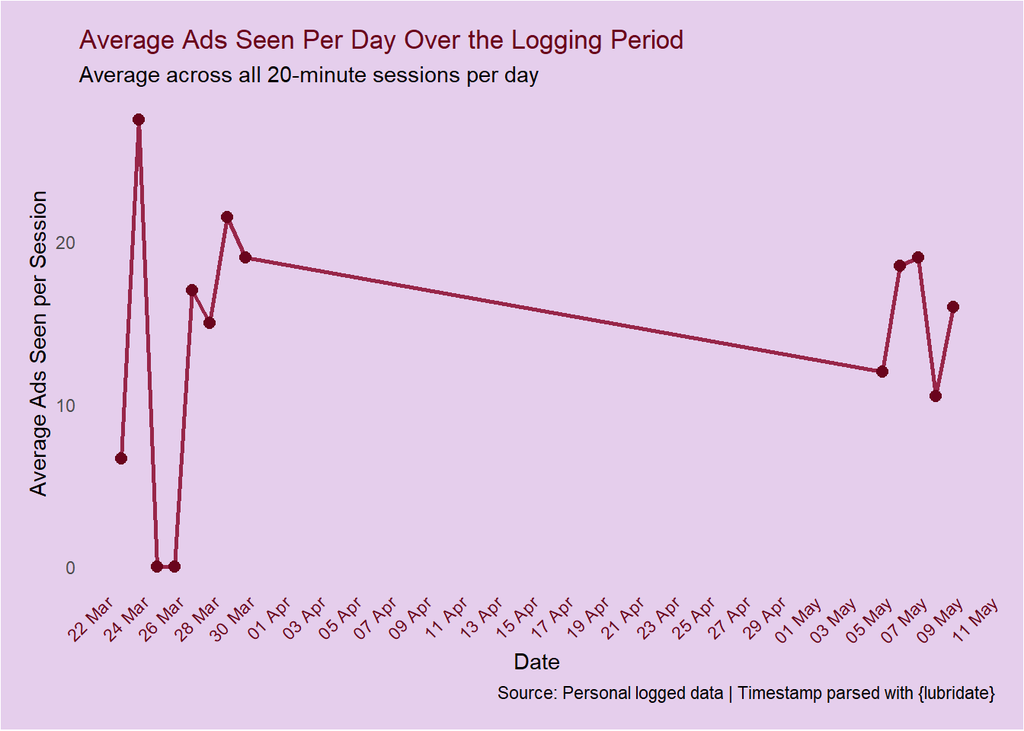

Ad exposure was higher during certain weeks, possibly reflecting increased phone usage during busier or more stressful periods. The gaps in the data reflect days where no logging sessions were recorded.

## Conclusion

This personal data story highlights how advertising is deeply embedded in everyday social media use. Even within short 20-minute sessions, users are exposed to a significant number of ads most of which go unnoticed or unengaged with. Additionally Each visualisation was built using {ggplot2}, mapping variables to aesthetic properties such as position, colour, and size, following the grammar of graphics framework.